# Workshop FLAI Dominando Data Science

```python
# Verificando a performance nos dados de validacao
pred = predict_model(modelo_combinado)
```

[output not shown]

|  | Model | MAE | MSE | RMSE | R2 | RMSLE | MAPE |
| --- | --- | --- | --- | --- | --- | --- | --- |
| 0 | Voting Regressor | 2886.2326 | 24992537.8613 | 4999.2537 | 0.8236 | 0.3896 | 0.2795 |

```python
# Aplicando o modelo final em todos os dados disponíveis
modelo_final = finalize_model(modelo_combinado)
```

[output not shown]

[output cut: 130 more lines]

[output not shown]

```python
# Salvando o modelo
save_model(modelo_final, 'meu-modelo-para-os-custos')
```

[output not shown]

[output cut: 32 more lines]

[output not shown]

```
Transformation Pipeline and Model Succesfully Saved
```

[output not shown]

```python
# Deploy Básico

def CustoSeguro(age, sex, bmi, children, smoker, region):
    dados0 = {'age': [age], 'sex': [sex], 'bmi': [bmi], 'children': [children], 'smoker': [smoker], 'region': [region]}
    dados = pd.DataFrame(dados0)

    modelo = load_model('C:/Users/mkrom/Desktop/Workshop-DDS-main/Workshop-DDS-main/meu-modelo-para-os-custos')

    pred = float(predict_model(modelo, data = dados)['Label'].round(2))
    valor = round(1.8*pred, 2)

    print(' ')
    print('Idade: {}'.format(age))
    print('Sexo: {}'.format(sex))
    print('IMC: {}'.format(bmi))
    print('Crianças: {}'.format(children))
    print('Fumante: {}'.format(smoker))
    print('Região: {}'.format(region))
    print(' ')
    print('Custo do Seguro: ${}'.format(pred))
    print('Valor de Venda: ${}'.format(valor))

CustoSeguro(age = 31, sex = 'male', bmi = 25, children = 0, smoker =  'yes', region = 'southwest')
```

[output not shown]

```
Transformation Pipeline and Model Successfully Loaded

Idade: 31
Sexo: male
IMC: 25
Crianças: 0
Fumante: yes
Região: southwest

Custo do Seguro: $23781.03
Valor de Venda: $42805.85
```

## **Machine Learning com PyCaret | Objetivo secundário: será que existem pessoas fraudando a variável *smoker*? Isto é, por conta das diferenças nos custos, será que há pessoas que digam que não são fumantes, quando na verdade são, na intenção de diminuir o custo do plano de saúde?**

### Pensando nesse caso, vamos desenvolver um modelo para prever se clientes do plano de saúde são potenciais fraudadores. De forma que seja possível enviar a informação para um departamento para uma investigação mais minuciosa sobre o potencial fraudador.

### Para isso, criaremos um modelo de classificação para prever a variável *smoker*, com o intuito de obter um modelo com a melhor taxa de acerto possível na predição. Os indivíduos que são classificados pelo modelo como fumantes, mas que sua observação conste que não seja, são os potenciais fraudadores. Um modelo que retorne probabilidades é desejável nesse caso, pois pode ser utilizado como escala no potencial de fraude.

```python
from pycaret.classification import *
```

```python
# configurações de pré-processamento e validação nos modelos utilizados adiante.

classificacao = setup(data = dados,
                  target = 'smoker',
                  normalize = True,
                  combine_rare_levels = True,
                  remove_outliers = True,
                  session_id = 1)
```

|  | Description | Value |
| --- | --- | --- |
| 0 | session_id | 1 |
| 1 | Target | smoker |
| 2 | Target Type | Binary |
| 3 | Label Encoded | no: 0, yes: 1 |
| 4 | Original Data | (1338, 7) |
| 5 | Missing Values | False |
| 6 | Numeric Features | 3 |
| 7 | Categorical Features | 3 |
| 8 | Ordinal Features | False |
| 9 | High Cardinality Features | False |
| 10 | High Cardinality Method | None |
| 11 | Transformed Train Set | (889, 12) |
| 12 | Transformed Test Set | (402, 12) |
| 13 | Shuffle Train-Test | True |
| 14 | Stratify Train-Test | False |
| 15 | Fold Generator | StratifiedKFold |
| 16 | Fold Number | 10 |
| 17 | CPU Jobs | -1 |
| 18 | Use GPU | False |
| 19 | Log Experiment | False |
| 20 | Experiment Name | clf-default-name |
| 21 | USI | 2985 |
| 22 | Imputation Type | simple |
| 23 | Iterative Imputation Iteration | None |
| 24 | Numeric Imputer | mean |
| 25 | Iterative Imputation Numeric Model | None |
| 26 | Categorical Imputer | constant |
| 27 | Iterative Imputation Categorical Model | None |
| 28 | Unknown Categoricals Handling | least_frequent |
| 29 | Normalize | True |
| 30 | Normalize Method | zscore |
| 31 | Transformation | False |
| 32 | Transformation Method | None |
| 33 | PCA | False |
| 34 | PCA Method | None |
| 35 | PCA Components | None |
| 36 | Ignore Low Variance | False |
| 37 | Combine Rare Levels | True |
| 38 | Rare Level Threshold | 0.100000 |
| 39 | Numeric Binning | False |
| 40 | Remove Outliers | True |
| 41 | Outliers Threshold | 0.050000 |
| 42 | Remove Multicollinearity | False |
| 43 | Multicollinearity Threshold | None |
| 44 | Clustering | False |
| 45 | Clustering Iteration | None |
| 46 | Polynomial Features | False |
| 47 | Polynomial Degree | None |
| 48 | Trignometry Features | False |
| 49 | Polynomial Threshold | None |
| 50 | Group Features | False |
| 51 | Feature Selection | False |
| 52 | Features Selection Threshold | None |
| 53 | Feature Interaction | False |
| 54 | Feature Ratio | False |
| 55 | Interaction Threshold | None |
| 56 | Fix Imbalance | False |
| 57 | Fix Imbalance Method | SMOTE |

[output not shown]

```python
modelos = compare_models(n_select = 7)
```

|  | Model | Accuracy | AUC | Recall | Prec. | F1 | Kappa | MCC | TT (Sec) |
| --- | --- | --- | --- | --- | --- | --- | --- | --- | --- |
| catboost | CatBoost Classifier | 0.9629 | 0.9927 | 0.9366 | 0.8880 | 0.9082 | 0.8851 | 0.8883 | 1.5560 |
| lightgbm | Light Gradient Boosting Machine | 0.9595 | 0.9899 | 0.9196 | 0.8868 | 0.8990 | 0.8738 | 0.8770 | 0.0300 |
| xgboost | Extreme Gradient Boosting | 0.9584 | 0.9894 | 0.9304 | 0.8719 | 0.8961 | 0.8703 | 0.8741 | 0.0700 |
| gbc | Gradient Boosting Classifier | 0.9528 | 0.9876 | 0.8971 | 0.8727 | 0.8810 | 0.8517 | 0.8546 | 0.0540 |
| dt | Decision Tree Classifier | 0.9472 | 0.9103 | 0.8500 | 0.8787 | 0.8611 | 0.8286 | 0.8309 | 0.0170 |
| ada | Ada Boost Classifier | 0.9449 | 0.9822 | 0.8745 | 0.8549 | 0.8614 | 0.8272 | 0.8296 | 0.0490 |
| lr | Logistic Regression | 0.9438 | 0.9846 | 0.8686 | 0.8542 | 0.8590 | 0.8240 | 0.8258 | 0.0170 |
| svm | SVM - Linear Kernel | 0.9438 | 0.0000 | 0.8794 | 0.8468 | 0.8591 | 0.8241 | 0.8271 | 0.0170 |
| rf | Random Forest Classifier | 0.9404 | 0.9853 | 0.8572 | 0.8500 | 0.8483 | 0.8115 | 0.8153 | 0.1060 |
| et | Extra Trees Classifier | 0.9281 | 0.9813 | 0.7827 | 0.8479 | 0.8063 | 0.7628 | 0.7685 | 0.0980 |
| lda | Linear Discriminant Analysis | 0.9280 | 0.9795 | 0.8232 | 0.8181 | 0.8190 | 0.7741 | 0.7754 | 0.0160 |
| knn | K Neighbors Classifier | 0.9168 | 0.9760 | 0.7033 | 0.8510 | 0.7659 | 0.7163 | 0.7237 | 0.0220 |
| ridge | Ridge Classifier | 0.9067 | 0.0000 | 0.6915 | 0.8124 | 0.7426 | 0.6864 | 0.6927 | 0.0160 |
| nb | Naive Bayes | 0.9022 | 0.9722 | 0.6967 | 0.7923 | 0.7349 | 0.6757 | 0.6818 | 0.0150 |
| qda | Quadratic Discriminant Analysis | 0.6939 | 0.4947 | 0.2203 | 0.3903 | 0.1927 | 0.0441 | 0.0762 | 0.0170 |

[output not shown]

```python
modelos_tunados = [tune_model(i) for i in modelos]
```

|  | Accuracy | AUC | Recall | Prec. | F1 | Kappa | MCC |
| --- | --- | --- | --- | --- | --- | --- | --- |
| 0 | 0.9213 | 0.9828 | 1.0000 | 0.7083 | 0.8293 | 0.7801 | 0.7997 |
| 1 | 0.9775 | 0.9820 | 1.0000 | 0.8947 | 0.9444 | 0.9304 | 0.9327 |
| 2 | 0.9888 | 0.9902 | 1.0000 | 0.9444 | 0.9714 | 0.9644 | 0.9651 |
| 3 | 0.9438 | 0.9877 | 1.0000 | 0.7727 | 0.8718 | 0.8366 | 0.8480 |
| 4 | 0.9663 | 0.9875 | 1.0000 | 0.8571 | 0.9231 | 0.9017 | 0.9060 |
| 5 | 0.9551 | 0.9812 | 1.0000 | 0.8182 | 0.9000 | 0.8714 | 0.8787 |
| 6 | 0.9551 | 0.9851 | 1.0000 | 0.8182 | 0.9000 | 0.8714 | 0.8787 |
| 7 | 0.9551 | 0.9828 | 1.0000 | 0.8182 | 0.9000 | 0.8714 | 0.8787 |
| 8 | 0.9551 | 0.9820 | 1.0000 | 0.8182 | 0.9000 | 0.8714 | 0.8787 |
| 9 | 0.9886 | 0.9950 | 1.0000 | 0.9444 | 0.9714 | 0.9643 | 0.9650 |
| Mean | 0.9607 | 0.9856 | 1.0000 | 0.8395 | 0.9111 | 0.8863 | 0.8931 |
| SD | 0.0196 | 0.0042 | 0.0000 | 0.0699 | 0.0416 | 0.0539 | 0.0487 |

```
2020-11-19 14:38:40,047 - INFO     - create_model_container: 22
2020-11-19 14:38:40,049 - INFO     - master_model_container: 22
2020-11-19 14:38:40,051 - INFO     - display_container: 8
2020-11-19 14:38:40,054 - INFO     - LogisticRegression(C=5.36, class_weight='balanced', dual=False,
                   fit_intercept=True, intercept_scaling=1, l1_ratio=None,
                   max_iter=1000, multi_class='auto', n_jobs=None, penalty='l2',
                   random_state=1, solver='lbfgs', tol=0.0001, verbose=0,
                   warm_start=False)
2020-11-19 14:38:40,056 - INFO     - tune_model() succesfully completed......................................
```

```python
melhor_modelo = blend_models(modelos_tunados, method = 'soft', choose_better = True)

# os melhores modelos soltam probabilidades, então podemos fazer a combinação 'soft'.
# o parametro 'choose_better' permite que a função retorne apenas o melhor modelo individual,
# caso a resultado combinado não tenha performance superior a todos os modelos individuais.
```

|  | Accuracy | AUC | Recall | Prec. | F1 | Kappa | MCC |
| --- | --- | --- | --- | --- | --- | --- | --- |
| 0 | 0.9438 | 0.9837 | 0.9412 | 0.8000 | 0.8649 | 0.8297 | 0.8341 |
| 1 | 0.9663 | 0.9894 | 0.9412 | 0.8889 | 0.9143 | 0.8933 | 0.8939 |
| 2 | 0.9551 | 0.9902 | 0.8235 | 0.9333 | 0.8750 | 0.8477 | 0.8502 |
| 3 | 0.9438 | 0.9820 | 1.0000 | 0.7727 | 0.8718 | 0.8366 | 0.8480 |
| 4 | 0.9775 | 0.9969 | 1.0000 | 0.9000 | 0.9474 | 0.9331 | 0.9352 |
| 5 | 0.9551 | 0.9898 | 1.0000 | 0.8182 | 0.9000 | 0.8714 | 0.8787 |
| 6 | 0.9775 | 0.9992 | 1.0000 | 0.9000 | 0.9474 | 0.9331 | 0.9352 |
| 7 | 0.9663 | 0.9922 | 0.9444 | 0.8947 | 0.9189 | 0.8977 | 0.8982 |
| 8 | 0.9551 | 0.9930 | 0.8889 | 0.8889 | 0.8889 | 0.8607 | 0.8607 |
| 9 | 0.9773 | 0.9967 | 0.9412 | 0.9412 | 0.9412 | 0.9271 | 0.9271 |
| Mean | 0.9618 | 0.9913 | 0.9480 | 0.8738 | 0.9070 | 0.8830 | 0.8861 |
| SD | 0.0125 | 0.0053 | 0.0547 | 0.0539 | 0.0301 | 0.0376 | 0.0359 |

```
2020-11-19 14:39:34,933 - INFO     - create_model_container: 30
2020-11-19 14:39:34,935 - INFO     - master_model_container: 30
2020-11-19 14:39:34,936 - INFO     - display_container: 9
2020-11-19 14:39:34,937 - INFO     - <catboost.core.CatBoostClassifier object at 0x0000018F4EF8C7F0>
2020-11-19 14:39:34,942 - INFO     - blend_models() succesfully completed......................................
```

```python
melhor_modelo
```

```
<catboost.core.CatBoostClassifier at 0x18f4ef8c7f0>
```

```python
pred = predict_model(melhor_modelo)
```

```
2020-11-19 14:39:35,337 - INFO     - Initializing predict_model()
2020-11-19 14:39:35,339 - INFO     - predict_model(estimator=<catboost.core.CatBoostClassifier object at 0x0000018F4EF8C7F0>, probability_threshold=None, encoded_labels=False, round=4, verbose=True, ml_usecase=MLUsecase.CLASSIFICATION, display=None)
2020-11-19 14:39:35,341 - INFO     - Checking exceptions
2020-11-19 14:39:35,343 - INFO     - Preloading libraries
2020-11-19 14:39:35,345 - INFO     - Preparing display monitor
```

|  | Model | Accuracy | AUC | Recall | Prec. | F1 | Kappa | MCC |
| --- | --- | --- | --- | --- | --- | --- | --- | --- |
| 0 | CatBoost Classifier | 0.9701 | 0.9958 | 0.9753 | 0.8876 | 0.9294 | 0.9105 | 0.9122 |

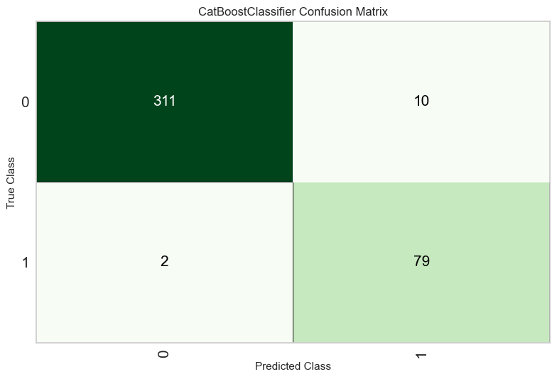

```
2020-11-19 14:39:36,101 - INFO     - Visual Rendered Successfully
2020-11-19 14:39:36,485 - INFO     - plot_model() succesfully completed......................................
```

```python
plot_model(melhor_modelo, plot = 'confusion_matrix')
```

```python
pred
```

|  | age | bmi | charges | sex_male | children_0 | children_1 | children_2 | children_3 | region_northeast | region_northwest | region_southeast | region_southwest | smoker | Label | Score |
| --- | --- | --- | --- | --- | --- | --- | --- | --- | --- | --- | --- | --- | --- | --- | --- |
| 0 | -1.413722 | 0.796716 | -0.954021 | 1.0 | 1.0 | 0.0 | 0.0 | 0.0 | 0.0 | 1.0 | 0.0 | 0.0 | no | no | 0.9994 |
| 1 | 1.296382 | 0.140978 | -0.157781 | 1.0 | 1.0 | 0.0 | 0.0 | 0.0 | 0.0 | 1.0 | 0.0 | 0.0 | no | no | 0.9994 |
| 2 | 0.868471 | 1.038304 | -0.367335 | 1.0 | 1.0 | 0.0 | 0.0 | 0.0 | 0.0 | 0.0 | 0.0 | 1.0 | no | no | 0.9996 |
| 3 | 0.725834 | 0.977497 | -0.237492 | 0.0 | 0.0 | 0.0 | 0.0 | 1.0 | 0.0 | 0.0 | 1.0 | 0.0 | no | no | 0.9996 |
| 4 | -1.271085 | -1.377574 | -0.916562 | 1.0 | 0.0 | 1.0 | 0.0 | 0.0 | 0.0 | 0.0 | 0.0 | 1.0 | no | no | 0.9981 |
| ... | ... | ... | ... | ... | ... | ... | ... | ... | ... | ... | ... | ... | ... | ... | ... |
| 397 | 1.296382 | 1.686647 | -0.140302 | 1.0 | 1.0 | 0.0 | 0.0 | 0.0 | 1.0 | 0.0 | 0.0 | 0.0 | no | no | 0.9994 |
| 398 | -1.342404 | 0.430226 | -0.934821 | 0.0 | 1.0 | 0.0 | 0.0 | 0.0 | 0.0 | 0.0 | 0.0 | 1.0 | no | no | 0.9994 |
| 399 | -1.342404 | -0.311794 | -0.887513 | 0.0 | 1.0 | 0.0 | 0.0 | 0.0 | 1.0 | 0.0 | 0.0 | 0.0 | no | no | 0.9985 |
| 400 | -0.914493 | -0.595290 | 0.308974 | 1.0 | 1.0 | 0.0 | 0.0 | 0.0 | 0.0 | 0.0 | 1.0 | 0.0 | yes | yes | 0.9832 |
| 401 | 0.725834 | -0.588716 | 1.055195 | 0.0 | 0.0 | 1.0 | 0.0 | 0.0 | 0.0 | 0.0 | 0.0 | 1.0 | no | no | 0.7386 |

402 rows × 15 columns

### Queremos selecionar aqueles em que a resposta observada é não fumante, mas que nosso modelo indica que é fumante. Vamos ordenar o resultado pelo Score, pois quanto mais alto, maior a probabilidade ser fumante e, portanto, maior o risco de ser um fraudador.

```python
possiveis_fraudes = pred[(pred['Label'] == 'yes') & (pred['smoker'] == 'no')].sort_values(by = 'Score', ascending = False)
possiveis_fraudes
```

|  | age | bmi | charges | sex_male | children_0 | children_1 | children_2 | children_3 | region_northeast | region_northwest | region_southeast | region_southwest | smoker | Label | Score |
| --- | --- | --- | --- | --- | --- | --- | --- | --- | --- | --- | --- | --- | --- | --- | --- |
| 45 | 1.510338 | -0.343019 | 1.393125 | 1.0 | 1.0 | 0.0 | 0.0 | 0.0 | 1.0 | 0.0 | 0.0 | 0.0 | no | yes | 0.9842 |
| 134 | 0.511878 | -0.506543 | 0.929091 | 1.0 | 1.0 | 0.0 | 0.0 | 0.0 | 0.0 | 0.0 | 0.0 | 1.0 | no | yes | 0.9240 |
| 334 | 0.369241 | -0.155665 | 1.544770 | 1.0 | 0.0 | 0.0 | 1.0 | 0.0 | 1.0 | 0.0 | 0.0 | 0.0 | no | yes | 0.8519 |
| 16 | -0.415263 | -1.311014 | 0.714291 | 1.0 | 1.0 | 0.0 | 0.0 | 0.0 | 0.0 | 1.0 | 0.0 | 0.0 | no | yes | 0.8246 |
| 42 | 0.797152 | -0.468744 | 0.530949 | 0.0 | 0.0 | 0.0 | 0.0 | 1.0 | 0.0 | 0.0 | 1.0 | 0.0 | no | yes | 0.8079 |
| 291 | 1.795612 | -0.983145 | 1.385466 | 1.0 | 0.0 | 1.0 | 0.0 | 0.0 | 0.0 | 1.0 | 0.0 | 0.0 | no | yes | 0.7755 |
| 242 | 1.652975 | 1.015296 | 1.504685 | 0.0 | 0.0 | 1.0 | 0.0 | 0.0 | 1.0 | 0.0 | 0.0 | 0.0 | no | yes | 0.5830 |
| 46 | -1.342404 | 0.760561 | 1.185123 | 1.0 | 0.0 | 1.0 | 0.0 | 0.0 | 0.0 | 0.0 | 1.0 | 0.0 | no | yes | 0.5735 |
| 67 | 1.296382 | -1.101474 | 0.731350 | 0.0 | 0.0 | 1.0 | 0.0 | 0.0 | 0.0 | 0.0 | 1.0 | 0.0 | no | yes | 0.5266 |
| 373 | 0.797152 | -0.545986 | 1.015511 | 0.0 | 1.0 | 0.0 | 0.0 | 0.0 | 1.0 | 0.0 | 0.0 | 0.0 | no | yes | 0.5024 |

### Portanto, o conjunto de dados acima é uma lista dos possíveis fraudadores, ordenada por aqueles mais prováveis de serem de fato fraudadores. Uma instituição poderia, por exemplo, tem um patamar em que caso a probabilidade seja maior que esse patamar, então uma investigação seria realizada. Por exemplo, se esse patamar fosse 70%, os individuos a serem investigados então seriam os seguintes:

```python
investigar = possiveis_fraudes[possiveis_fraudes['Score'] > 0.7]
investigar
```

|  | age | bmi | charges | sex_male | children_0 | children_1 | children_2 | children_3 | region_northeast | region_northwest | region_southeast | region_southwest | smoker | Label | Score |
| --- | --- | --- | --- | --- | --- | --- | --- | --- | --- | --- | --- | --- | --- | --- | --- |
| 45 | 1.510338 | -0.343019 | 1.393125 | 1.0 | 1.0 | 0.0 | 0.0 | 0.0 | 1.0 | 0.0 | 0.0 | 0.0 | no | yes | 0.9842 |
| 134 | 0.511878 | -0.506543 | 0.929091 | 1.0 | 1.0 | 0.0 | 0.0 | 0.0 | 0.0 | 0.0 | 0.0 | 1.0 | no | yes | 0.9240 |
| 334 | 0.369241 | -0.155665 | 1.544770 | 1.0 | 0.0 | 0.0 | 1.0 | 0.0 | 1.0 | 0.0 | 0.0 | 0.0 | no | yes | 0.8519 |
| 16 | -0.415263 | -1.311014 | 0.714291 | 1.0 | 1.0 | 0.0 | 0.0 | 0.0 | 0.0 | 1.0 | 0.0 | 0.0 | no | yes | 0.8246 |
| 42 | 0.797152 | -0.468744 | 0.530949 | 0.0 | 0.0 | 0.0 | 0.0 | 1.0 | 0.0 | 0.0 | 1.0 | 0.0 | no | yes | 0.8079 |
| 291 | 1.795612 | -0.983145 | 1.385466 | 1.0 | 0.0 | 1.0 | 0.0 | 0.0 | 0.0 | 1.0 | 0.0 | 0.0 | no | yes | 0.7755 |

### Finalizando o modelo para uso futuro

```python
modelo_final = finalize_model(melhor_modelo)
```

[output not shown]

```python
# Salvando o modelo
save_model(modelo_final, 'meu-modelo-para-smoker')
```

[output not shown]

```
Transformation Pipeline and Model Succesfully Saved
```

[output not shown]

```python
# Deploy Básico

def DetectorDeFumante(age, sex, bmi, children, region, charges):
    dados0 = {'age': [age], 'sex': [sex], 'bmi': [bmi], 'children': [children], 'region': [region], 'charges': [charges]}
    dados = pd.DataFrame(dados0)

    modelo = load_model('C:/Users/mkrom/Desktop/Workshop-DDS-main/Workshop-DDS-main/meu-modelo-para-smoker')

    pred = predict_model(modelo, data = dados)
    resp = 'NÃO' if pred['Label'][0] == 'no' else 'SIM'
    prob = pred['Score'][0]


    print(' ')
    print('Idade: {}'.format(age))
    print('Sexo: {}'.format(sex))
    print('IMC: {}'.format(bmi))
    print('Crianças: {}'.format(children))
    print('Região: {}'.format(region))
    print('Custos: {}'.format(charges))
    print(' ')
    print('É fumante?: {}, com probabilidade {:.2f}%'.format(resp, 100*prob))
```

```python
DetectorDeFumante(age = 30, sex = 'male', bmi = 25, children = 0, region = 'southwest', charges = 20000)
```

[output not shown]

```
Transformation Pipeline and Model Successfully Loaded

Idade: 30
Sexo: male
IMC: 25
Crianças: 0
Região: southwest
Custos: 20000

É fumante?: SIM, com probabilidade 96.13%
```

## **Considerações Finais**

### Veja que o conjunto de dados utilizado nessa análise é um dos clássicos da literatura. Não é um conjunto de dados que poderíamos dizer que representa dados da realidade, pois já estão muito bem resumidos e pré-processados. Esses conjuntos de dados são menos interessantes para se utilizar em projetos de portfólio do que dados que venham de uma fonte mais representativa da realidade.

### No entanto, uma maneira de tornar o uso de tais conjuntos é tentar colocar uma nova ótica, uma nova abordagem, uma nova maneira de enxergar o problema. É o que nós fizemos ao colocar a atenção da modelagem numa das variáveis que a principio era preditora do problema tradicionalmente abordado, contextualizando com um possível problema de negócio.

### Isso demonstra sua capacidade de ir além, de explorar novos caminhos, de ser diferente dos demais. É isso que muitos recrutadores estão procurando, então, não perca as chances de demonstrar suas habilidades, em qualquer contexto de aplicação que seja.

### E agora, com os modelos salvos, podemos construir uma aplicação web para disponibilizar um acesso ao modelo bastante conveniente para o usuário final. Faremos isso com o *streamlit*, e disponibilizaremos online através do site https://share.streamlit.io/.

https://share.streamlit.io/gitflai/workshop-dds/main/medical.py